# Elementary Statistics using Excel

Nov 08, 2018

## Chapter 5 Section 1 Objectives

### Probability Distributions

- Define random variable and probability distributions
- Determine When a potential probability distribution actually satisfies the necessary requirements.
- Given a probability distribution, compute the mean and standard deviation, then use those results to determine whether the results are significantly low or significantly high.

## Definitions

- **random variable** - a variable (generally \(x\)) that has a sngle numerical value, determined by chance, for each outcome of a procedure.
- **probability distribution** a description that gives the probability for each value of the random variable. It is often expressed in the format of a table, formula, or graph.
- **discrete randome variable** - a collection of values that is finite or countable. (Coin Flips)
- **continuous random variable** - Infinitely many values, and the collection is not countable. (Body Temp)
- **expected value** - the mean value of a dsicrete random variable. Often denoted as \(E\).

## Requirements for Probability Distributions

1. There is a numerical random variable \(x\) and its number values are associated with corresponding probability values.
2. \(0 \leq P(x) \leq 1\) for every value of the random varaible \(x\).

## Sum of two random Dice Rolls

| Sum of dice | Die roll Possibilities | \(P(x)\) | Sum of dice | Die roll Possibilities | \(P(x)\) |
| --- | --- | --- | --- | --- | --- |
| 2 | (1,1) | 1/36 | 8 | (2,6)(3,5)(4,4)(5,3)(6,2) | 5/36 |
| 3 | (1,2)(2,1) | 2/36 | 9 | (3,6)(4,5)(5,4)(6,3) | 4/36 |
| 4 | (1,3)(2,2)(3,1) | 3/36 | 10 | (4,6)(5,5)(6,4) | 3/36 |
| 5 | (1,4)(2,3)(3,2)(4,1) | 4/36 | 11 | (5,6)(6,5) | 2/36 |
| 6 | (1,5)(2,4)(3,3)(4,2)(5,1) | 5/36 | 12 | (6,6) | 1/36 |
| 7 | (1,6)(2,5)(3,4)(4,3)(5,2)(6,1) | 6/36 |  |  |  |

## Do the die rolls meet the criteria?

1. The variable \(x\) is a numerical random variable and its values are associated with the previous table.
2. \(\Sigma P(x) = \frac{1}{36} + \frac{2}{36} + \frac{3}{36} + \frac{4}{36} + \frac{5}{36} + \frac{6}{36} + \frac{5}{36} + \frac{4}{36} + \frac{3}{36} + \frac{2}{36} + \frac{1}{36} = 1\)
3. Each value of \(P(x)\) is between 0 and 1.

## Histogram

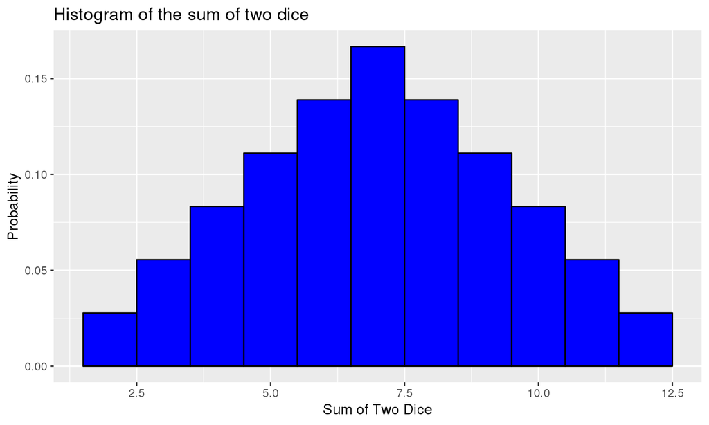

## Parameters of Probability Distribution

- \(\mu = \Sigma [ x \cdot P(x)]\) also known as \(E[x]\)
- \(\sigma^2 = \Sigma [x-\mu^2] \cdot P(x)\)
- \(E[x^2] = \Sigma [x^2 \cdot P(x)]\)
- \(\sigma^2 = E[x^2] - (E[x])^2\)
- \(\sigma = \sqrt{E[x^2] - (E[x])^2}\)

## Significance

- Significantly Low - Falls below or equal to \(\mu - 2 \cdot \sigma\)
- Significantly High - Falls above or equal to \(\mu + 2 \cdot \sigma\)
- Not significant - Falls between \(\mu - 2 \cdot \sigma\) and \(\mu + 2 \cdot \sigma\).

## Chapter 5 Section 2 Objectives

### Binomial Probability Distributions

- Describe a binomial probability distribution and find the probability values for a binomial distribution.
- Compute the mean and standard deviation for a binomial distribution, then use those results to determine whether the results are significantly low or significantly high.

## Definitions

- **binomial probability distribution** - results from a procedure that meets the following:
  - The procedure has a fixed number of trials.
  - The trials must be independent.
  - Each trial must have all outcomes classified into exactly 2 categories. (Bernoulli)
  - The probability of remains the same on all trials.

## Binomial Probability Distributions

- \(P(S) = p\), \(p\) is the probability of success
- \(P(F) = 1 - p = q\), \(q\) is the probability of failure
- \(n\) is a fixed number of trials
- \(x\) is a specific number of success in \(n\) trials.
- \(P(x)\) is the probability of getting exactly \(x\) successes in \(n\) trials

## Binomial Formula

\[ P(x) = \binom{n}{x} \cdot p^x \cdot q^{n-x}\] \[ \textrm{for }x = 1,2,3,....,n\]

## Using Excel

- BINOM.DIST
  - =BINOM.DIST(x,n,p,0)
  - the last 0 means you want the the probability of \(x\) of success.
  - Change the last 0 to a 1 and it will give you the cummalitve proability to \(x\) success. So the probability of getting x and fewer successes.

## Mean, Variance and Standard deviation of Binomial Distribution

- \(\mu = np\)
- \(\sigma^2 = npq\)
- \(\sigma = \sqrt{npq}\)